# Entrega práctica general curso R

Elena Campo Montalvo - 15-01-2022 -

# 1 Trabajo con datos de **`palmerpenguins`**

Se analizan datos de 344 pingüinos de tres especies distintas donde la base “penguins” contiene información de la isla, la longitud y profundidad del pico (mm), longitud de la aleta, tamaño, sexo.

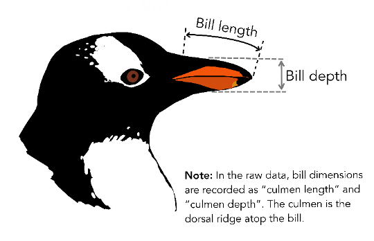

Figura: Longitud y profundidad del pico del pingüino

## 1.1 Instalación del paquete, carga de la biblioteca y de los datos

```r
install.packages("palmerpenguins", repos = "http://cran.us.r-project.org")
library(palmerpenguins)
data(package = 'palmerpenguins')
pinguinos_df <- palmerpenguins::penguins
```

```r
head(pinguinos_df)
```

```
## # A tibble: 6 × 8
##   species island bill_length_mm bill_depth_mm flipper_length_… body_mass_g sex
##   <fct>   <fct>           <dbl>         <dbl>            <int>       <int> <fct>
## 1 Adelie  Torge…           39.1          18.7              181        3750 male
## 2 Adelie  Torge…           39.5          17.4              186        3800 fema…
## 3 Adelie  Torge…           40.3          18                195        3250 fema…
## 4 Adelie  Torge…           NA            NA                 NA          NA <NA>
## 5 Adelie  Torge…           36.7          19.3              193        3450 fema…
## 6 Adelie  Torge…           39.3          20.6              190        3650 male
## # … with 1 more variable: year <int>
```

## 1.2 Ejercicio 1

> Calcular el número de individuos totales, masculinos y femeninos por especie.

```r
table(pinguinos_df$sex, pinguinos_df$species)
```

```
##
##          Adelie Chinstrap Gentoo
##   female     73        34     58
##   male       73        34     61
```

> Calcular la media, desviación estándar, valor mínimo y máximo de la longitud y profundidad del pico, la longitud de la aleta y el tamaño.

```r
campos <- c("Media", "Desviación estándar", "Mínimo", "Máximo")

long_pico <- c(mean(na.omit(pinguinos_df$bill_length_mm)), sd(na.omit(pinguinos_df$bill_length_mm)), min(na.omit(pinguinos_df$bill_length_mm)), max(na.omit(pinguinos_df$bill_length_mm)))

prof_pico <- c(mean(na.omit(pinguinos_df$bill_depth_mm)), sd(na.omit(pinguinos_df$bill_depth_mm)), min(na.omit(pinguinos_df$bill_depth_mm)), max(na.omit(pinguinos_df$bill_depth_mm)))

long_aleta <- c(mean(na.omit(pinguinos_df$flipper_length_mm)), sd(na.omit(pinguinos_df$flipper_length_mm)), min(na.omit(pinguinos_df$flipper_length_mm)), max(na.omit(pinguinos_df$flipper_length_mm)))

peso <- c(mean(na.omit(pinguinos_df$body_mass_g)), sd(na.omit(pinguinos_df$body_mass_g)), min(na.omit(pinguinos_df$body_mass_g)), max(na.omit(pinguinos_df$body_mass_g)))

# Se construye la matriz de resultados
resultados <- rbind(campos, long_pico, prof_pico,long_aleta, peso)

resultados
```

```
##            [,1]               [,2]                  [,3]     [,4]
## campos     "Media"            "Desviación estándar" "Mínimo" "Máximo"
## long_pico  "43.9219298245614" "5.45958371392653"    "32.1"   "59.6"
## prof_pico  "17.1511695906433" "1.97479315681678"    "13.1"   "21.5"
## long_aleta "200.915204678363" "14.0617136793569"    "172"    "231"
## peso       "4201.75438596491" "801.954535698095"    "2700"   "6300"
```

## 1.3 Ejercicio 2

> Instalar paquete `ggplot2` y cargarlo en memoria. También paquetes para la utillización del addin ‘ggplotAssist’

```r
install.packages("ggplot2", repos = "http://cran.us.r-project.org")
library(ggplot2)
```

```r
devtools::install_github("cardiomoon/editData")
```

```r
devtools::install_github("cardiomoon/ggplotAssist")
```

> Realizar un gráfico de barras que represente el número de individuos muestreados de cada especie en cada isla, representando las especies en diferentes colores (chinstrap – morado, gentoo – azul, adelie – naranja).

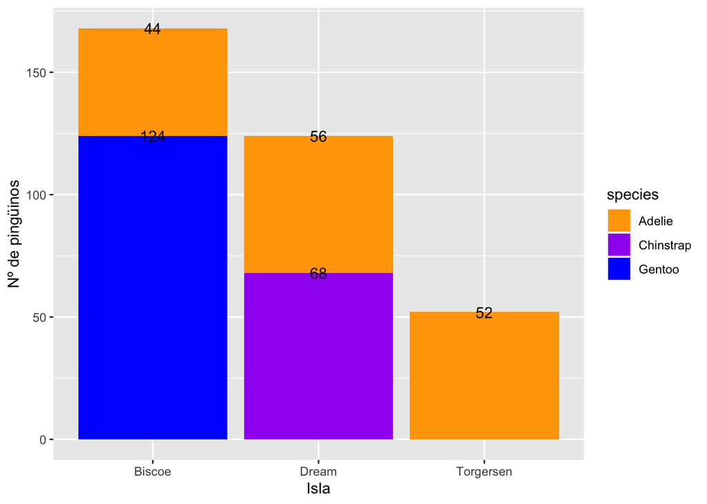

```r
ggplot(data = pinguinos_df, aes(x=island, fill = species)) +
  geom_bar() +
  labs(x="Isla", y="Nº de pingüinos") +
  geom_text(aes(label=..count..),stat='count',position=position_stack()) +
  scale_fill_manual (values = c("Adelie" = "orange", "Chinstrap" = "purple", "Gentoo" = "blue"))
```

> Contesta a las siguientes preguntas: ¿qué especies se han muestreado en las tres islas? ¿cuántos individuos se han muestreado de la isla Dream?

El total de individuos de la isla Dream,de las especies Adelie y Chinstrap, es 124.

## 1.4 Ejercicio 3

> Crear un gráfico multipanel de cajas y bigotes del tamaño de los pingüinos según su sexo, donde aparezca un panel para cada especie.

[figure not shown]

```r
ggplot(data = na.omit(pinguinos_df)) +
  geom_boxplot(aes(y = body_mass_g, x=sex)) +
  facet_grid(cols=vars(species)) +
  labs(x="Isla", y="Nº de pingüinos")
```

> Contesta a las siguientes preguntas:

> ¿Qué especie tiene mayor tamaño? ¿En qué especie las hembras y los machos tienen un tamaño más similar?
- La especie de mayor tamaño es la *Gentoo*.
- La especie en la que las hembras y los machos tienen un tamaño similar es la *Chinstrap*.